# How Variable are these Trees Anyway?

Aurora Owens

November 2nd, 2016

```r
library(ggplot2)
library(dplyr)
library(tree)
library(randomForest)
library(maptree)
library(gridExtra)
```

One of my main assumptions in the CVIM method is that trees are quite variable. Variable enough that by making small changes in the structure of the data I could derive different values from them. Well, the output from the current code is not as I hoped, distributions are extremely consisitant/ not variable. Is this a bug, or are there larger issues with my assumptions?

### The Simulated Data

This is taken from ’sampling.Rmd`

```r
set.seed(1)

x1 <- rnorm(5000)

set.seed(2)

x2 <-  3* x1 +rnorm(5000)

set.seed(3)

y <- 5*x1 + 4*x2 + rnorm(5000)

data <- data.frame(y,x1,x2)
```

### Variablilty

There are a number of ways I can think of to measure a tree’s variablility, but I’ll start with the mean squared predictive error of $Y$ ~ $X_1, X_2$

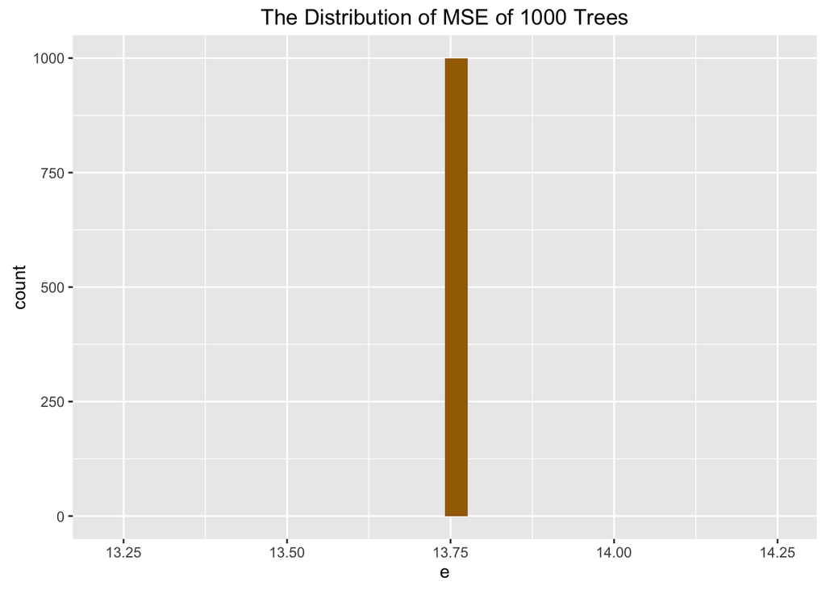

```r
e <- rep(0,1000)

set.seed(444)
for(i in 1:1000){
  t <- tree(y ~x1 + x2, data)
  yhat <- predict(t)
  e[i] <- mean((data$y - yhat)^2)
}

ggplot(data = as.data.frame(e)) + geom_histogram(aes(x = e), fill = "#a16c01") + ggtitle("The Distribution of MSE of 1000 Trees")
```

### Number of splits

Another way we can compare trees for variablity is looking at their number of splits

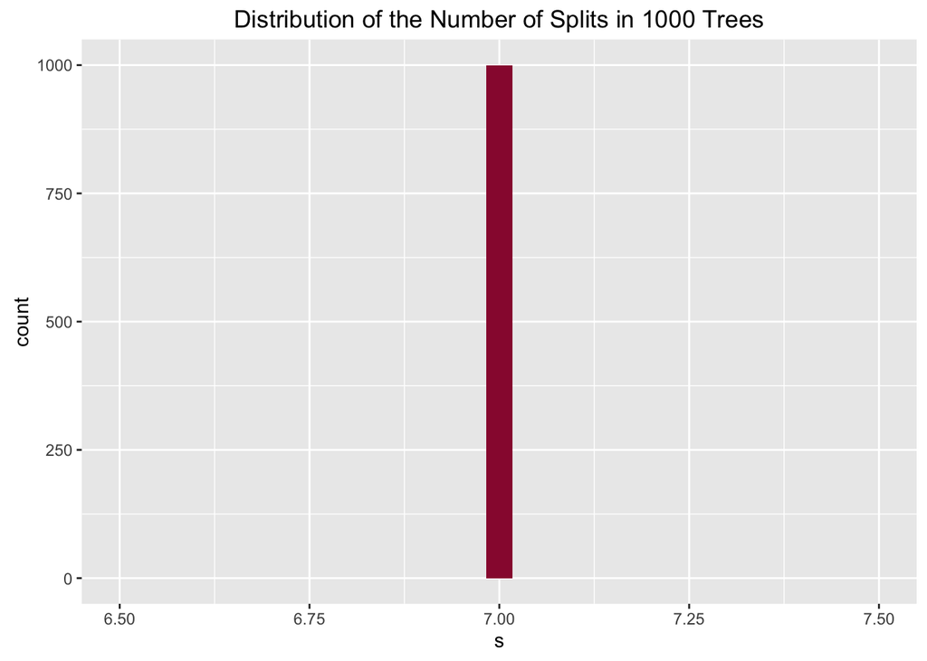

```r
s <- rep(0,1000)

#set.seed(444)
for(i in 1:1000){
  t <- tree(y ~., data)
  splits.cutleft <- t$frame$splits[,1]
  splits.cutleft <- gsub("<", "", splits.cutleft)
  splits.cutleft[splits.cutleft == ""] <- NA
  s[i]<- length(splits.cutleft[complete.cases(splits.cutleft)])
}

ggplot(data = as.data.frame(s)) + geom_histogram(aes(x = s), fill = "#99183c" ) +ggtitle("Distribution of the Number of Splits in 1000 Trees")
```

#### First Split

What if we look at which variable was split on first?

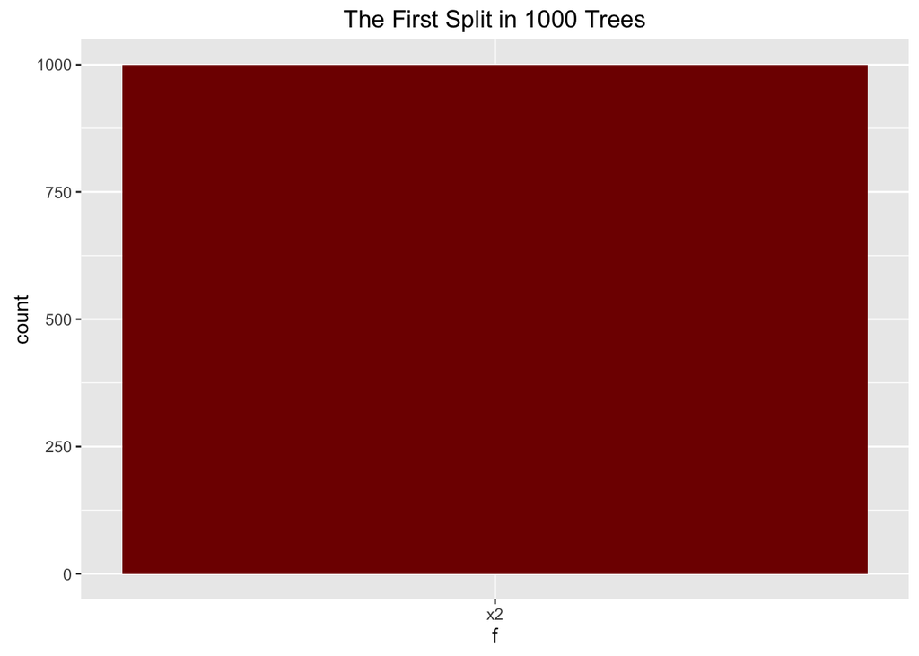

```r
f <- rep("none",1000)

#set.seed(444)
for(i in 1:1000){
  t <- tree(y ~., data)
  f[i] <- as.character(t$frame$var[1])
}

ggplot(data = as.data.frame(f)) + geom_bar(aes(x = f), fill = "#800000") +ggtitle("The First Split in 1000 Trees")
```

```r
filter(as.data.frame(f), f != "x2")
```

```
## [1] f
## <0 rows> (or 0-length row.names)
```

These trees all very similar - too similar to create a usefull distribution from their results.

### Permuting the data

Let’s see how these change when x2 is permuted (blindly, not with conditional permutation)

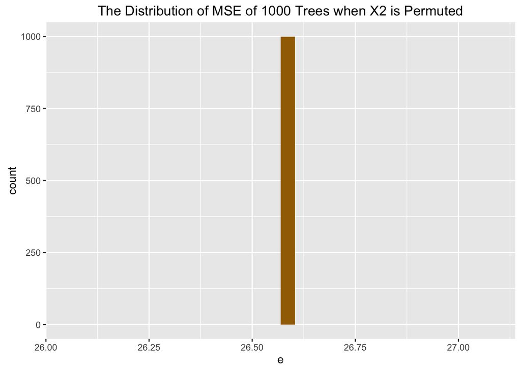

```r
e <- rep(0,1000)

data1 <- data

set.seed(444)
for(i in 1:1000){
  data1$x2 <- sample(data1$x2)
  t <- tree(y ~x1 + x2, data1)
  yhat <- predict(t)
  e[i] <- mean((data1$y - yhat)^2)
}

ggplot(data = as.data.frame(e)) + geom_histogram(aes(x = e), fill = "#a16c01") + ggtitle("The Distribution of MSE of 1000 Trees when X2 is Permuted")
```

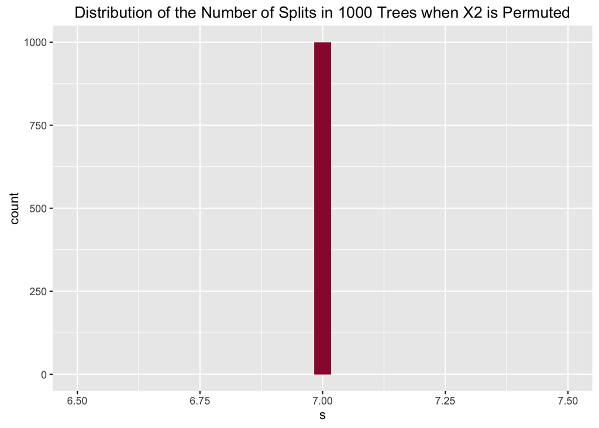

```r
s <- rep(0,1000)
data2 <- data
#set.seed(444)
for(i in 1:1000){
  data$x2 <- sample(data$x2)
  t <- tree(y ~., data2)
  splits.cutleft <- t$frame$splits[,1]
  splits.cutleft <- gsub("<", "", splits.cutleft)
  splits.cutleft[splits.cutleft == ""] <- NA
  s[i]<- length(splits.cutleft[complete.cases(splits.cutleft)])
}

ggplot(data = as.data.frame(s)) + geom_histogram(aes(x = s), fill = "#99183c" ) +ggtitle("Distribution of the Number of Splits in 1000 Trees when X2 is Permuted")
```

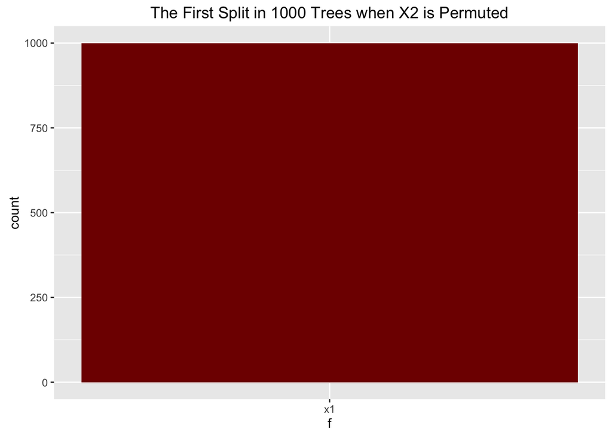

```r
f <- rep("none",1000)

data3 <- data
#set.seed(444)
for(i in 1:1000){
  data3$x2 <- sample(data3$x2)
  t <- tree(y ~., data3)
  f[i] <- as.character(t$frame$var[1])
}

ggplot(data = as.data.frame(f)) + geom_bar(aes(x = f), fill = "#800000") +ggtitle("The First Split in 1000 Trees when X2 is Permuted")
```